# Seventh Week: Generalized Linear Models

Murder or suicide

Ali Gorji

2018-04-28 02:46:36

> با توجه به سوالات مرگ و میر در آمریکا به سوالات زیر پاسخ دهید.

۱. از میان متغیرهای داده مرگ و میر یک زیرمجموعه ایی بدون حشو در نظر بگیرید. ماتریس همبستگی متغیرهای مختلف را به دست آورده و سپس رسم نمایید. علاوه بر این نمودار پراکنش متغیرهای انتخاب شده را همزمان نسبت به هم رسم نمایید.

```r
library(readr)
```

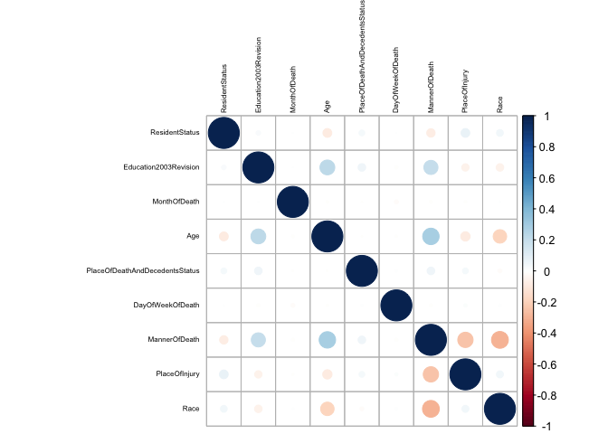

```r
library(ggplot2)
library(highcharter)
library(dplyr)
library(corrplot)
library(h2o)
library(ggthemes)

murder = read.csv("data/murder_suicide.csv")
clean_murder = murder %>% filter(EducationReportingFlag == 1 & AgeType!=9) %>% mutate(AgeInYear = (AgeType == 1)*Age, MannerOfDeath = (MannerOfDeath==2)*1) %>% select(ResidentStatus, Education2003Revision, MonthOfDeath, Sex, Age = AgeInYear, PlaceOfDeathAndDecedentsStatus, MaritalStatus, DayOfWeekOfDeath, InjuryAtWork, MannerOfDeath, MethodOfDisposition, Autopsy, PlaceOfInjury, Race = RaceRecode5)
clean_murder %>% select_if(is.numeric) %>% cor(use="complete.obs")  %>% corrplot(tl.cex = 0.5,tl.col = "black")
```

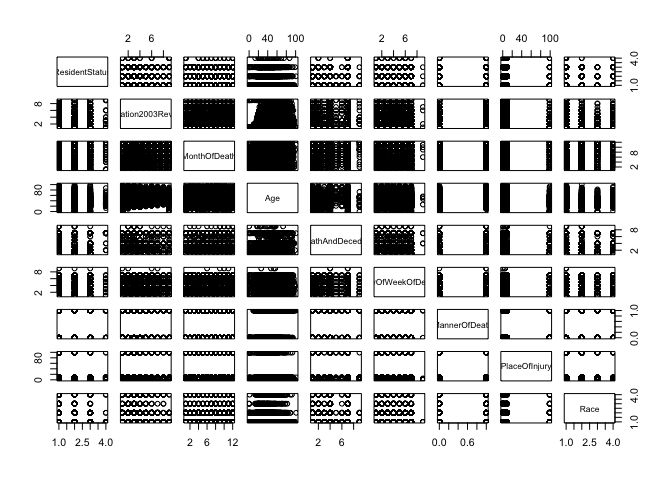

```r
clean_murder = clean_murder[sample(nrow(clean_murder)),]
# filter to reduce size of data so we can plot it
clean_murder %>% select_if(is.numeric) %>% filter(row_number() < 10000) %>% plot()
```

۲. اثر هر یک از متغیرهای جنسیت، نژاد،آموزش، سن و نحوه تدفین را بر مرگ یا خودکشی ارزیابی کنید.

برای متغیرهای کتگوریال من از تست Chi2 استفاده می کنم تا تاثیر این متغیر ها را بر روی متغیر کتگوریال دیگر، یعنی نحوه مرگ، بیابم. اما برای بررسی تاثیر سن، که متغیری پیوسته است بر روی نحوه مرگ، با توجه به تعداد بالای داده ها و فرض نرمال بودن، از تست One Way Anova استفاده می کنیم تا ببینیم سن تاثیر به سزایی روی میانگین دو گروه دارد یا خیر.

```r
chisq.test(clean_murder$Sex, clean_murder$MannerOfDeath)
```

```
##
##  Pearson's Chi-squared test with Yates' continuity correction
##
## data:  clean_murder$Sex and clean_murder$MannerOfDeath
## X-squared = 25.369, df = 1, p-value = 4.735e-07
```

```r
chisq.test(clean_murder$Race, clean_murder$MannerOfDeath)
```

```
##
##  Pearson's Chi-squared test
##
## data:  clean_murder$Race and clean_murder$MannerOfDeath
## X-squared = 13736, df = 3, p-value < 2.2e-16
```

```r
chisq.test(clean_murder$Education2003Revision, clean_murder$MannerOfDeath)
```

```
##
##  Pearson's Chi-squared test
##
## data:  clean_murder$Education2003Revision and clean_murder$MannerOfDeath
## X-squared = 3551.2, df = 8, p-value < 2.2e-16
```

```r
oneway.test(Age ~ MannerOfDeath, data = clean_murder)
```

```
##
##  One-way analysis of means (not assuming equal variances)
##
## data:  Age and MannerOfDeath
## F = 4024.2, num df = 1, denom df = 24460, p-value < 2.2e-16
```

```r
chisq.test(clean_murder$MethodOfDisposition, clean_murder$MannerOfDeath)
```

```
##
##  Pearson's Chi-squared test
##
## data:  clean_murder$MethodOfDisposition and clean_murder$MannerOfDeath
## X-squared = 4438.3, df = 6, p-value < 2.2e-16
```

از آن جایی که در تمامی تست ها مقدار p value بسیار کوچک بود می توانیم تاثیر به سزای تمام این پارامتر ها بر روی نحوه مرگ را بیابیم. در موارد مرزی تر می توانستیم از کشیدن نمودار و تصویرسازی برای بررسی بیشتر استفاده کنیم، اما در اینجا نتیجه های محکمی از تست ها به دست آوردیم و نیازی به این کار حس نمی شود.

۳. با استفاده از مدل رگرسیون لاجستیک یک مدل به داده ها برازش دهید و سپس آن را نقص یابی کنید.

```r
numericed_murder = clean_murder %>% mutate(Sex = (Sex == "M")*1, MaritalStatus = (MaritalStatus == "D")*2 + (MaritalStatus == "M")*1) %>% mutate(MannerOfDeath = as.factor(MannerOfDeath))
model = glm(MannerOfDeath ~ ResidentStatus + Education2003Revision + MonthOfDeath + Sex + Age + PlaceOfDeathAndDecedentsStatus + MaritalStatus + DayOfWeekOfDeath + MannerOfDeath + PlaceOfInjury + Race, family = "binomial", data = numericed_murder)
summary.glm(model)
```

```
##
## Call:
## glm(formula = MannerOfDeath ~ ResidentStatus + Education2003Revision +
##     MonthOfDeath + Sex + Age + PlaceOfDeathAndDecedentsStatus +
##     MaritalStatus + DayOfWeekOfDeath + MannerOfDeath + PlaceOfInjury +
##     Race, family = "binomial", data = numericed_murder)
##
## Deviance Residuals:
##     Min       1Q   Median       3Q      Max
## -7.1741  -0.8049   0.4973   0.7132   3.3626
##
## Coefficients:
##                                  Estimate Std. Error z value Pr(>|z|)
## (Intercept)                     0.0679923  0.0635412   1.070    0.285
## ResidentStatus                 -0.1514511  0.0190848  -7.936 2.09e-15 ***
## Education2003Revision           0.2468555  0.0076691  32.188  < 2e-16 ***
## MonthOfDeath                   -0.0048480  0.0031865  -1.521    0.128
## Sex                             0.0638667  0.0267688   2.386    0.017 *
## Age                             0.0241060  0.0006992  34.479  < 2e-16 ***
## PlaceOfDeathAndDecedentsStatus  0.0688621  0.0053050  12.981  < 2e-16 ***
## MaritalStatus                   0.3123020  0.0167087  18.691  < 2e-16 ***
## DayOfWeekOfDeath               -0.0032277  0.0053617  -0.602    0.547
## PlaceOfInjury                  -0.0411001  0.0012201 -33.686  < 2e-16 ***
## Race                           -0.8125837  0.0162512 -50.002  < 2e-16 ***
## ---
## Signif. codes:  0 '***' 0.001 '**' 0.01 '*' 0.05 '.' 0.1 ' ' 1
##
## (Dispersion parameter for binomial family taken to be 1)
##
##     Null deviance: 64715  on 54366  degrees of freedom
## Residual deviance: 52285  on 54356  degrees of freedom
## AIC: 52307
##
## Number of Fisher Scoring iterations: 5
```

```r
improvedModel = glm(MannerOfDeath ~ ResidentStatus + Education2003Revision + Age + PlaceOfDeathAndDecedentsStatus + MaritalStatus + MannerOfDeath + PlaceOfInjury + Race, family = "binomial", data = numericed_murder)
summary.glm(improvedModel)
```

```
##
## Call:
## glm(formula = MannerOfDeath ~ ResidentStatus + Education2003Revision +
##     Age + PlaceOfDeathAndDecedentsStatus + MaritalStatus + MannerOfDeath +
##     PlaceOfInjury + Race, family = "binomial", data = numericed_murder)
##
## Deviance Residuals:
##     Min       1Q   Median       3Q      Max
## -7.1776  -0.8042   0.4973   0.7139   3.3555
##
## Coefficients:
##                                 Estimate Std. Error z value Pr(>|z|)
## (Intercept)                     0.074014   0.051465   1.438     0.15
## ResidentStatus                 -0.150975   0.019082  -7.912 2.53e-15 ***
## Education2003Revision           0.245389   0.007639  32.123  < 2e-16 ***
## Age                             0.024142   0.000699  34.539  < 2e-16 ***
## PlaceOfDeathAndDecedentsStatus  0.069364   0.005300  13.087  < 2e-16 ***
## MaritalStatus                   0.309487   0.016659  18.578  < 2e-16 ***
## PlaceOfInjury                  -0.041011   0.001217 -33.700  < 2e-16 ***
## Race                           -0.811772   0.016237 -49.996  < 2e-16 ***
## ---
## Signif. codes:  0 '***' 0.001 '**' 0.01 '*' 0.05 '.' 0.1 ' ' 1
##
## (Dispersion parameter for binomial family taken to be 1)
##
##     Null deviance: 64715  on 54366  degrees of freedom
## Residual deviance: 52293  on 54359  degrees of freedom
## AIC: 52309
##
## Number of Fisher Scoring iterations: 5
```

ابتدا با کمک داده های خلاصه شده از بخش اول مدلی تشکیل دادیم و اقدام به حذف پارامترهای با تاثیر پایین در مدل کردیم و به مدل بهبود یافته رسیدیم.  
پارامتر دیگری به نام Icd10Code نیز در پارامتر ها موجود بود که به طور دقیق کد پزشکی هر کیس را مشخص می کرد. با بررسی جدول مربوط به مقادیر آن دیدم تعداد حالت های آن به شدت زیاد است و احساس کردم دقیق مشخص کردن این مقدار شاید وابستگی ای با حقیقت اتفاق افتاده داشته باشد و استفاده از آن با اینکه دقت بالایی در فیت شدن به ما بدهد شاید درست نباشد و ترجیح دادم از آن در تهیه مدلم استفاده نکنم.

۴. با استفاده از سه نمودار خروجی مدل را نسبت به داده واقعی ارزیابی کنید.

```r
predicted_murder = numericed_murder
predicted_murder$prediction = (predict(improvedModel, newdata = numericed_murder, type = "response")>.5)*1
```

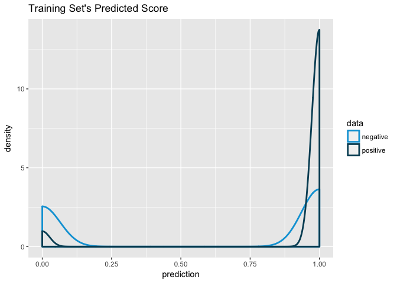

```r
ggplot(predicted_murder, aes( prediction, color = MannerOfDeath)) +
geom_density(size = 1) +
ggtitle("Training Set's Predicted Score") +
scale_color_economist(name = "data", labels = c("negative", "positive"))
```

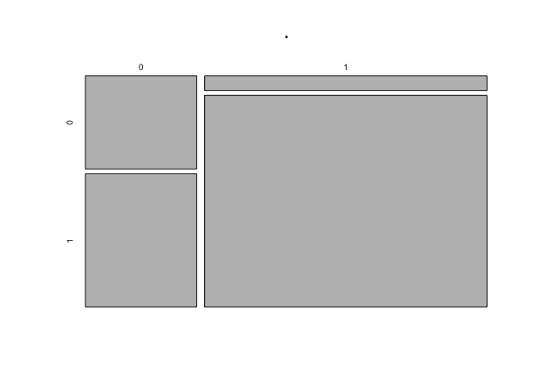

```r
table(predicted_murder$MannerOfDeath,predicted_murder$prediction) %>% plot()
```

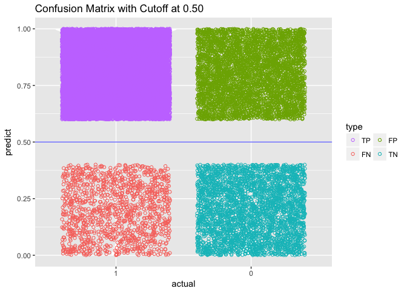

```r
cm_info = ConfusionMatrixInfo( data = predicted_murder, predict = "prediction",
                               actual = "MannerOfDeath", cutoff = .5 )
cm_info$plot
```

۵. ابتدا ۲۰ درصد داده را به صورت تصادفی به عنوان تست در نظر بگیرید. مدل را با استفاده از ۸۰ درصد باقی مانده برازش دهید. با استفاده از پارامتر قطع ۰.۵ نتایج را برای داده تست پیش بینی کنید. سپس کمیت های زیر را محاسبه کنید.

- P: positive samples
- N: negative samples
- TP: true positive TP (eqv. with hit)
- TN: true negative (eqv. with correct rejection)
- FP: false positive (eqv. with false alarm, Type I error)
- FN: false negative (eqv. with miss, Type II error)
- Accuracy (ACC) ACC = (TP+TN)/(P+T)
- False positive rate (FPR): 1- TN/N
- True positive rate (TPR): TP/P

مشابه آنچه در کلاس گفته شد نمایشی از چهار کمیت TN, TP,FP,FN به همراه داده ها رسم نمایید.

```r
k = as.integer(0.2 * count(numericed_murder))
train = numericed_murder[1:k,]
test = numericed_murder[(k+1):nrow(numericed_murder),]
fit = glm(MannerOfDeath ~ ResidentStatus + Education2003Revision + Age + PlaceOfDeathAndDecedentsStatus + MaritalStatus + MannerOfDeath + PlaceOfInjury + Race, family = "binomial", data = numericed_murder)
test$prediction = predict(fit, newdata = test, type = "response")
train$prediction = predict(fit, newdata = train, type = "response")
```

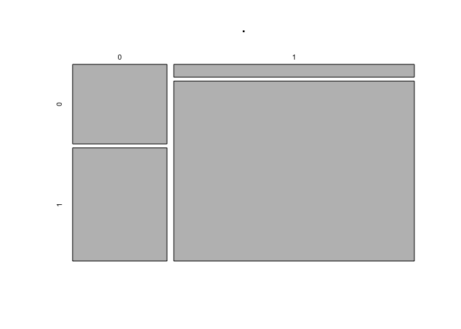

```r
cut_off = 0.5
# Add predicted column to check with real data
test = test %>% mutate(PredictedMannerOfDeath = (prediction > cut_off)*1)
P = sum(test$PredictedMannerOfDeath == 1)
N = sum(test$PredictedMannerOfDeath == 0)
TP = test %>% filter(PredictedMannerOfDeath == 1 & PredictedMannerOfDeath == MannerOfDeath) %>% nrow()
TN = test %>% filter(PredictedMannerOfDeath == 0 & PredictedMannerOfDeath == MannerOfDeath) %>% nrow()
FP = test %>% filter(PredictedMannerOfDeath == 1 & PredictedMannerOfDeath != MannerOfDeath) %>% nrow()
FN = test %>% filter(PredictedMannerOfDeath == 0 & PredictedMannerOfDeath != MannerOfDeath) %>% nrow()
ACC = (TP+TN)/(P+N)
FPR = 1-TN/N
TPR = TP/P

table(test$MannerOfDeath,test$PredictedMannerOfDeath) %>% plot()
```

۶. نمودار صحت مدل (accuracy) را بر حسب مقادیر مختلف قطع برای داده تست رسم نمایید. کدام پارامتر قطع بالاترین صحت را در پیش بینی داراست؟

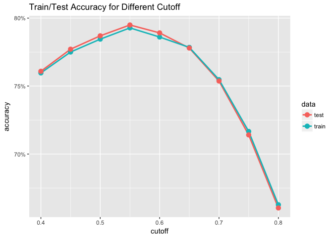

```r
accuracy_info = AccuracyCutoffInfo(train = train, test = test, predict = "prediction", actual = "MannerOfDeath")
accuracy_info$plot
```

```r
cut_off = 0.55
# Add predicted column to check with real data
test = test %>% mutate(PredictedMannerOfDeath = (prediction > cut_off)*1)
ACC = (TP+TN)/(P+N)
ACC
```

```
## [1] 0.7869591
```

۷. نمودار ROC را برای داده های قسمت قبل رسم نمایید. همچنین نقطه مربوط به بهترین پارامتر قطع را مشخص نمایید.

وزن ها بر اساس وزن های استفاده شده در کلاس درس تنظیم شد.بر این اساس که FN برای ما اهمیت بیشتری از FP دارد. اما دو برابر بودن وزن آن چیزی بود که حدودی است و شاید جای بحث بیشتری دارد.

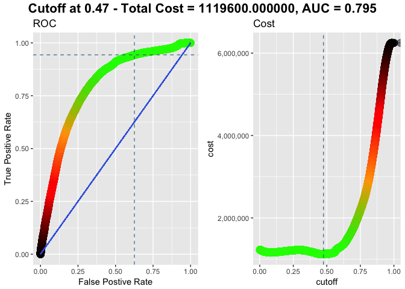

```r
cost_fp = 100
cost_fn = 200

roc_info = ROCInfo( data = test, predict = "prediction", actual = "MannerOfDeath", cost.fp = cost_fp, cost.fn = cost_fn )
grid.draw(roc_info$plot)
```

۸. با قرار دادن کمیت nfolds = 5 و با استفاده از H20 مدل مساله را بسازید و نتیجه حاصل را ارزیابی کنید.

```r
h2o.init()
```

```
##  Connection successful!
##
## R is connected to the H2O cluster:
##     H2O cluster uptime:         1 hours 24 minutes
##     H2O cluster timezone:       Asia/Tehran
##     H2O data parsing timezone:  UTC
##     H2O cluster version:        3.19.0.4257
##     H2O cluster version age:    19 days
##     H2O cluster name:           H2O_started_from_R_ali_hlc488
##     H2O cluster total nodes:    1
##     H2O cluster total memory:   1.61 GB
##     H2O cluster total cores:    4
##     H2O cluster allowed cores:  4
##     H2O cluster healthy:        TRUE
##     H2O Connection ip:          localhost
##     H2O Connection port:        54321
##     H2O Connection proxy:       NA
##     H2O Internal Security:      FALSE
##     H2O API Extensions:         XGBoost, Algos, AutoML, Core V3, Core V4
##     R Version:                  R version 3.4.3 (2017-11-30)
```

```r
hcor_murder <- as.h2o(numericed_murder)
h2oglm = h2o.glm(y = "MannerOfDeath", x=c("ResidentStatus", "Education2003Revision", "Age", "PlaceOfDeathAndDecedentsStatus", "MaritalStatus", "MannerOfDeath", "PlaceOfInjury", "Race"),
                training_frame =  hcor_murder , family="binomial",nfolds = 5)
summary(h2oglm)
```

```
## Model Details:
## ==============
##
## H2OBinomialModel: glm
## Model Key:  GLM_model_R_1524862343596_37
## GLM Model: summary
##     family  link                                regularization
## 1 binomial logit Elastic Net (alpha = 0.5, lambda = 2.646E-4 )
##   number_of_predictors_total number_of_active_predictors
## 1                          7                           7
##   number_of_iterations   training_frame
## 1                    4 numericed_murder
##
## H2OBinomialMetrics: glm
## ** Reported on training data. **
##
## MSE:  0.1546096
## RMSE:  0.3932043
## LogLoss:  0.4809256
## Mean Per-Class Error:  0.3002422
## AUC:  0.7957589
## Gini:  0.5915178
## R^2:  0.2369942
## Residual Deviance:  52292.97
## AIC:  52308.97
##
## Confusion Matrix (vertical: actual; across: predicted) for F1-optimal threshold:
##            0     1    Error          Rate
## 0       7405  7946 0.517621   =7946/15351
## 1       3233 35783 0.082863   =3233/39016
## Totals 10638 43729 0.205621  =11179/54367
##
## Maximum Metrics: Maximum metrics at their respective thresholds
##                         metric threshold    value idx
## 1                       max f1  0.546897 0.864898 244
## 2                       max f2  0.081656 0.929735 380
## 3                 max f0point5  0.673976 0.848164 189
## 4                 max accuracy  0.554635 0.794894 241
## 5                max precision  0.957664 0.944628  12
## 6                   max recall  0.003845 1.000000 399
```

[output cut: 82 more lines]

```
## 4   0.48133
## 5   0.48133
##
## Variable Importances: (Extract with `h2o.varimp`)
## =================================================
##
## Standardized Coefficient Magnitudes: standardized coefficient magnitudes
##                            names coefficients sign
## 1                  PlaceOfInjury     0.614879  NEG
## 2                           Race     0.504616  NEG
## 3                            Age     0.487598  POS
## 4          Education2003Revision     0.417346  POS
## 5                  MaritalStatus     0.239100  POS
## 6 PlaceOfDeathAndDecedentsStatus     0.134453  POS
## 7                 ResidentStatus     0.081697  NEG
```

۹. آیا ما میتوانیم سرویسی به قضات ارایه کنیم تا با استفاده از اطلاعات مرگ بتوانند موارد مشکوک به قتل را از خودکشی تفکیک دهند؟

جواب این سوال کاملا بستگی به دقت مورد نیاز دارد. از طرفی می دانیم همواره استثنائاتی موجود است و هیچ گاه نمی توانیم به طور قطعی پیش بینی کنیم، همینطور اگر دقت پیش بینی پایین باشد کمک شایانی نمی تواند به تصمیم گیری بکند.در مدل فعلی دقت پایین نیست ولی در حدی که بتواند تصمیم گیری دقیق بکند نیز بالا نیست. استفاده از این مدل برای کمکی به تشخیص این موضوع بر اساس شواهد دیگر بد نیست ولی به نظر من نمی تواند به عنوان سرویس دقیقی برای تصمیم گیری در مواقع مشکوک استفاده شود.